# Лабораторная работа №2

Pасчёт сети Fast Ethernet

Устинова В. В.

Российский университет дружбы народов, Москва, Россия

26 сентября 2026

# Информация

## Докладчик

- Устинова Виктория Вадимовна
- студент НПИбд-01-24
- Российский университет дружбы народов

## Цель работы

Цель данной работы — изучение принципов технологий Ethernet и Fast Ethernet и практическое освоение методик оценки работоспособности сети, построенной на базе технологии Fast Ethernet

## Задание и конфигурации сети.

Ознакомится с вариантами конфигурации сети Fast Ethernet.Топология сети включает два повторителя класса 2 соединенных между собой и шесть сегментов витой пары

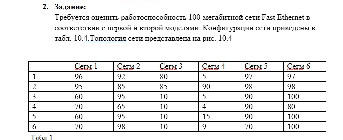

## Значения задержек компонентов.

Использовать значения задержек компонентов сети Fast Ethernet из таблицы 10.2 для расчета времени двойного оборота. Тк категория витой пары не указана принять витую пару категории 5

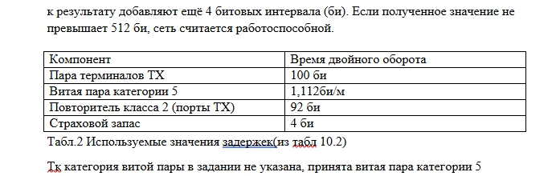

В таблице приведены значения времени двойного оборота для терминалов кабеля и повторителей

## Определение наихудшего пути.

Определить наихудший путь — самый длинный путь между двумя узлами домена коллизий. В данной топологии он проходит через сегмент 4 между двумя повторителями и включает три кабельных сегмента и два повторителя класса II.

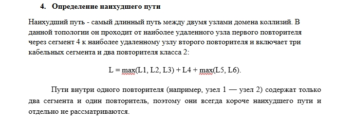

Формула для расчёта: L = max(L1, L2, L3) + L4 + max(L5, L6).

## Проверка по первой модели.

Проверить работоспособность сети по первой модели. Во всех вариантах длина каждого сегмента не превышает 100 м, поэтому ограничение на длину сегмента выполнено. Результаты расчёта диаметра домена коллизий приведены в таблице 3

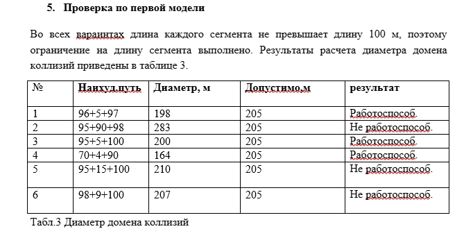

В таблице показаны диаметры для всех вариантов и результаты: варианты 1, 3, 4 — работоспособны; 2, 5, 6 — неработоспособны.

## Проверка по второй модели (вариант 1).

Проверить работоспособность сети по второй модели. Выполнить подробный расчёт для варианта 1: наихудший путь — сегмент 1 (96 м) — повторитель — сегмент 4 (5 м) — повторитель — сегмент 5 (97 м)

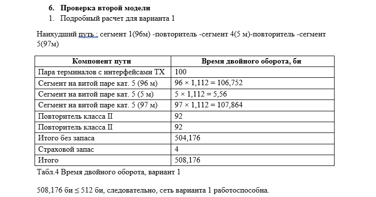

В таблице 4 приведён расчёт времени двойного оборота для варианта 1: итого 508,176 би ≤ 512 би, сеть работоспособна.

## Результаты для всех вариантов.

Выполнить расчёт времени двойного оборота для всех вариантов по формуле PDV = 100 + 1,112·L + 2·92 + 4 = 288 + 1,112·L, где L — длина наихудшего пути в метрах

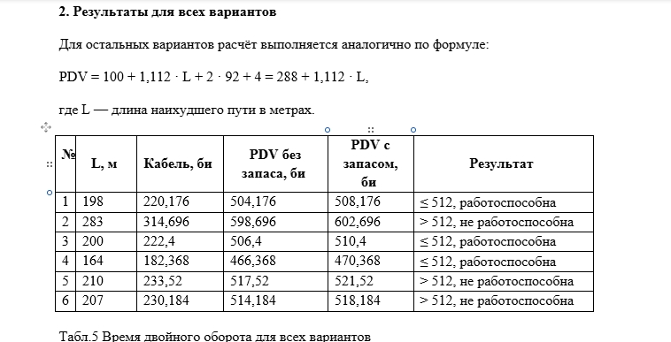

В таблице 5 приведены результаты: варианты 1, 3, 4 — работоспособны; 2, 5, 6 — неработоспособны.

## Итоговый вывод о работоспособности.

Свести результаты проверки по первой и второй моделям в итоговую таблицу и сделать вывод о работоспособности сети для каждого варианта

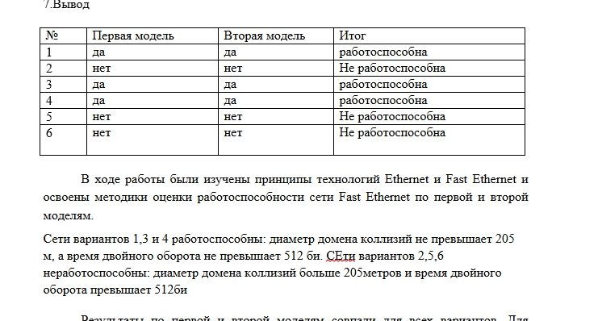

В таблице 7 показано: варианты 1, 3, 4 — работоспособны; 2, 5, 6 — неработоспособны.

## Выводы

В ходе работы были изучены принципы технологий Ethernet и Fast Ethernet и освоены методики оценки работоспособности сети Fast Ethernet по первой и второй моделям. Сети вариантов 1, 3 и 4 работоспособны: диаметр домена коллизий не превышает 205 м, а время двойного оборота не превышает 512 би. Сети вариантов 2, 5 и 6 неработоспособны: диаметр домена коллизий больше 205 метров и время двойного оборота превышает 512 би. Результаты по первой и второй моделям совпали для всех вариантов